# Deep Learning — Assignment 6 — Score sheet

Sixth assignment for the 2024 Deep Learning course (NWI-IMC070) of the Radboud University.

Please enter your names and group number.**Names:**

**Group:**

## Objectives

In this assignment you will

1. Construct a PyTorch `DataSet`.
2. Train and modify a transformer network.
3. Learn how to use a model based on the PyTorch documentation.
4. Experiment with a translation dataset.

## Required software

If you haven't done so already, you will need to install the following additional libraries:

- `torch` for PyTorch,

All libraries can be installed with `pip install`.

```python
%matplotlib inline
import math
import time
from random import Random
from typing import (List, Optional)
import numpy as np
import torch
from torch import nn
from torch.utils.data import (IterableDataset, DataLoader)
import matplotlib.pyplot as plt
from IPython import display

# fix the seed, so outputs are exactly reproducible
torch.manual_seed(12345);

# Use the GPU if available
def detect_device():
    if torch.cuda.is_available():
        return torch.device("cuda")
    elif torch.backends.mps.is_available():
        return torch.device("mps")
    else:
        return torch.device("cpu")
device = detect_device()
```

## 6.1 Learning to calculate (5 points)

In this assignment we are going to train a neural network to do mathematics. When communicating between humans, mathematics is expressed with words and formulas. The simplest of these are formulas with a numeric answer. For example, we might ask what is `100+50`, to which the answer is `150`.

To teach a computer how to do this task, we are going to need a dataset.

Below is a function that generates a random formula. Study it, and see if you understand its parameters.

```python
def random_integer(length: int, signed: bool = True, rng: Random = Random()):
    max = int(math.pow(10, length))
    min = -max if signed else 0
    return rng.randint(min, max)

def random_formula(complexity: int, signed: bool = True, rng: Random = Random()):
    """
    Generate a random formula of the form "a+b" or "a-b".
    complexity is the maximum number of digits in the numbers.
    """
    a = random_integer(complexity, signed, rng)
    b = random_integer(complexity, False, rng)
    is_addition = not signed or rng.choice([False, True])
    if is_addition:
        return (f"{a}+{b}", str(a + b))
    else:
        return (f"{a}-{b}", str(a - b))
```

```python
seed = 123456
random_formula(3, rng=Random(seed))
```

```
('649+864', '1513')
```

Note that the `rng` argument allows us to reproduce the same random numbers, which you can verify by running the code below multiple times. But if you change the seed to `None` then the random generator is initialized differently each time.

```python
def random_formulas(complexity, signed, count, seed):
    """
    Iterator that yields the given count of random formulas
    """
    rng = Random(seed)
    for i in range(count):
        yield random_formula(complexity, signed, rng=rng)

for q, a in random_formulas(3, True, 5, seed):
    print(f'{q} = {a}')
```

```
649+864 = 1513
-940-819 = -1759
954-2 = 952
-896-274 = -1170
-762-954 = -1716
```

We are going to treat these expressions as sequences of tokens, where each character is a token. In addition we will need tokens to denote begin-of-sequence and end-of-sequence, as well as padding, for which we will use `'<bos>'`, `'<eos>'`, and `'<pad>'` respectively, as was done in the lecture.

### Creating a vocabulary

The vocabulary is the set of all possible tokens.

To store the vocabulary, we will use a helper class:

```python
class Vocab:
    """A vocabulary."""
    def __init__(self, tokens: List[str], specials: Optional[List[str]] = None):
        """
        Construct a vocabulary given a list of tokens, and an optional list of special tokens
        """
        self.tokens = tokens
        if specials is not None:
            self.tokens.extend(specials)
        self.tokens.sort()
        self.token_to_idx = {token: idx for idx, token in enumerate(self.tokens)}

    def __len__(self):
        return len(self.tokens)

    def __getitem__(self, token):
        return self.lookup_index(token)

    def lookup_index(self, token: str) -> int:
        return self.token_to_idx[token]

    def lookup_indices(self, tokens: List[str]) -> List[int]:
        return [self.lookup_index(token) for token in tokens]

    def lookup_token(self, index: int) -> str:
        return self.tokens[index]

    def lookup_tokens(self, indices: List[int]) -> List[str]:
        return [self.lookup_token(index) for index in indices]
```

For this dataset we know beforehand what the vocabulary will be, so we can easily define it by hand.

**6.1 a Add comment(a) What are the tokens in this dataset? Complete the code below. (1 point)**

*Grading:*

- 1 point for correct vocabulary.
- It doesn't matter whether tokens go in the first argument or in the `specials`.
- You should have 15 tokens in the output below.
- Note: there is no '=' token used in this dataset. -0.5 point if it is included.

```python
### BEGIN ANSWER
# We need 15 tokens: the digits 0..9, '+', '-', and tokens to represent
# begin-of-sequence, end-of-sequence, and padding.
vocab = Vocab([*[str(i) for i in range(10)],'+','-'],
              specials=['<bos>','<eos>','<pad>'])
### END ANSWER
```

We can print the vocabulary to double check that it makes sense:

```python
print('Vocabulary size:', len(vocab))
print('Vocabulary:', vocab.tokens)
```

```
Vocabulary size: 15
Vocabulary: ['+', '-', '0', '1', '2', '3', '4', '5', '6', '7', '8', '9', '<bos>', '<eos>', '<pad>']
```

We are now ready to tokenize and encode formula.

**6.1 b Add comment(b) Complete the code below. (1 point)**

Hint: [d2l chapter 9.2](https://d2l.ai/chapter_recurrent-neural-networks/text-sequence.html) includes an example of tokenizing a string.

*Grading:*

- 1 point for correct answer.
- The function must return a list, and output must include encoded `<eos>` token.
- The output of the code below should exactly match the anwer model, because the seed is fixed.

```python
def tokenize_and_encode(string: str, vocab=vocab) -> List[int]:
    ### BEGIN ANSWER
    return vocab.lookup_indices(list(string) + ['<eos>'])
    ### END ANSWER
```

Let's test it on a random formula:

```python
q, a = random_formula(3, rng=Random(seed))
print('The question', q, 'and answer', a)
print('are encoded as', tokenize_and_encode(q), 'and', tokenize_and_encode(a))

# Check tokenize_and_encode
assert ''.join(vocab.lookup_tokens(tokenize_and_encode(q))) == q + '<eos>'
assert len(tokenize_and_encode(q)) == len(q) + 1
assert tokenize_and_encode("1+2") == vocab.lookup_indices(['1','+','2','<eos>'])
```

```
The question 649+864 and answer 1513
are encoded as [8, 6, 11, 0, 10, 8, 6, 13] and [3, 7, 3, 5, 13]
```

### Padding and trimming

Next, to be able to work with a whole dataset of these encoded sequences, they all need to be the same length.

**6.1 c Add comment(c) Implement the function below that pads or trims the encoded token sequence as needed. (1 point)**

Hint: see [d2l section 10.5.3](http://d2l.ai/chapter_recurrent-modern/machine-translation-and-dataset.html#loading-sequences-of-fixed-length) for a very similar function.

*Grading:*

- 1 point for correct code. The output of the test below should exactly match the answer model (assuming the vocabulary is encoded the same).

```python
def pad_or_trim(tokens: List[int], target_length: int, vocab=vocab):
    ### BEGIN ANSWER
    padding = [vocab['<pad>']] * max(0, target_length - len(tokens))
    return tokens[:target_length] + padding
    ### END ANSWER
```

```python
# pad or trim q to get a sequence of 10 tokens
pad_or_trim(tokenize_and_encode(q), 10)
```

```
[8, 6, 11, 0, 10, 8, 6, 13, 14, 14]
```

```python
# Check pad_or_trim
assert len(pad_or_trim([1,2,3,4,5],10)) == 10
assert len(pad_or_trim(list(range(20)),10)) == 10
assert vocab.lookup_tokens(pad_or_trim([1,2,3,4,5],10)[5:]) == ['<pad>','<pad>','<pad>','<pad>','<pad>'], \
       f"Incorrect padding tokens, found {vocab.to_tokens(pad_or_trim([1,2,3,4,5],10)[5:])}"
```

### Translating tokens

We can use `vocab.lookup_tokens` to convert the encoded token sequence back to something more readable:

```python
vocab.lookup_tokens(pad_or_trim(tokenize_and_encode(q), 10))
```

```
['6', '4', '9', '+', '8', '6', '4', '<eos>', '<pad>', '<pad>']
```

For convenience, we define the `decode_tokens` function to convert entire lists or tensors:

```python
def decode_tokens(t, vocab=vocab):
    # convert a list, tensor, or array of encoded tokens
    if isinstance(t, torch.Tensor):
        t = t.detach().cpu()
    else:
        t = torch.tensor(t)
    return np.asarray(vocab.lookup_tokens(list(t.flatten()))).reshape(*t.shape)

# convert all tokens at once
print(decode_tokens([pad_or_trim(tokenize_and_encode('513+1323'), 10),
                     pad_or_trim(tokenize_and_encode('412+42'), 10)]))
```

```
[['5' '1' '3' '+' '1' '3' '2' '3' '<eos>' '<pad>']
 ['4' '1' '2' '+' '4' '2' '<eos>' '<pad>' '<pad>' '<pad>']]
```

### Creating a dataset

The most convenient way to use a data generating function for training a neural network is to wrap it in a PyTorch `Dataset`. In this case, we will use an IterableDataset, which can be used as an iterator to walk over the samples in the dataset.

**6.1 d Add comment(d) Complete the code below. (1 point)**

*Grading:*

- 1 point for a correct implementation.
- `__iter__` should yield a pair `(q,a)`.
- `q` and `a` should be tokenized, padded, and converted to torch tensors.
- You are allowed to use the `random_formulas` function.
- Note that the vocab argument is passed on to `tokenize_and_encode` and `pad_or_trim`, if you forget this strange things could happen if the vocabulary changes. But for this assignment that is not a big problem.

```python
class FormulaDataset(IterableDataset):
    def __init__(self, complexity, signed, count, seed=None, vocab=vocab):
        self.seed = seed
        self.complexity = complexity
        self.signed = signed
        self.count = count
        self.vocab = vocab
        self.max_question_length = 2 * complexity + 3
        self.max_answer_length = complexity + 3

    def __len__(self):
        return self.count

    ### BEGIN ANSWER
    def __iter__(self):
        # Restart at the same seed in every epoch
        rng = Random(self.seed)
        for i in range(self.count):
            q, a = random_formula(self.complexity, self.signed, rng=rng)
            q = torch.tensor(pad_or_trim(tokenize_and_encode(q, self.vocab),
                                         self.max_question_length, self.vocab))
            a = torch.tensor(pad_or_trim(tokenize_and_encode(a, self.vocab),
                                         self.max_answer_length, self.vocab))
            yield q, a
    ### END ANSWER
```

**6.1 e Add comment(e) Define a training set with 10000 formulas and a validation set with 5000 formulas, both with complexity 3. (1 point)**

Note: make sure that the training and validation set are different.

*Score: You must use different seeds and the sizes need to be correct.*

```python
complexity = 3
signed = True
### BEGIN ANSWER
train_seed = 12345
val_seed   = 12346
train_data = FormulaDataset(complexity, signed, 10000, seed=train_seed)
val_data   = FormulaDataset(complexity, signed, 5000,  seed=val_seed)
### END ANSWER
```

As usual, we wrap each dataset in a `DataLoader` to create minibatches.

```python
# Define data loaders
batch_size = 125
data_loaders = {
    'train': torch.utils.data.DataLoader(train_data, batch_size=batch_size),
    'val':   torch.utils.data.DataLoader(val_data, batch_size=batch_size),
}
```

```python
# The code below checks that the datasets are defined correctly
train_loader = data_loaders['train']
val_loader = data_loaders['val']

from typing import Tuple
from typing_extensions import assert_type
for (name, loader), expected_size in zip(data_loaders.items(), [10000,5000]):
    first_batch = next(iter(loader))
    assert len(first_batch) == 2, \
           f"The {name} dataset should yield (question, answer) pairs when iterated over."
    assert torch.is_tensor(first_batch[0]), \
           f"The questions in the {name} dataset should be torch.tensors"
    assert tuple(first_batch[0].shape) == (batch_size, 2*complexity+3), \
           f"The questions in the {name} dataset should be of size (batch_size, max_question_length), i.e. {batch_size,2*complexity+3}, found {tuple(first_batch[0].shape)}"
    assert first_batch[0].dtype in [torch.int32,torch.int64], \
           f"The questions in the {name} dataset should be encoded as integers, found {first_batch[0].dtype}"
    assert torch.equal(next(iter(loader))[0], next(iter(loader))[0]), \
           f"The {name} dataset should be deterministic, it should produce the same data each time"
    assert all([len(batch[0]) == batch_size for batch in iter(loader)]), \
           f"Batches should all have the right size. Perhaps the batch size does not evenly divide the dataset size?"
    assert sum([len(batch[0]) for batch in iter(loader)]) == expected_size, \
           f"{name} dataset does not have the right size, expected {expected_size}, found {sum([len(batch[0]) for batch in iter(loader)])}."
assert not torch.equal(next(iter(train_loader))[0], next(iter(val_loader))[0]), \
       "The training data and validation data should not be the same"
```

## 6.2 Transformer inputs (10 points)

There is a detailed description of the transformer model in Bishop chapter 12, and in [d2l chapter 11](http://d2l.ai/chapter_attention-mechanisms-and-transformers/index.html). We will not use the code from the d2l book, and instead use [PyTorch's built-in Transformer layers](https://pytorch.org/docs/stable/nn.html#transformer-layers).

However, some details we still need to implement ourselves.

### Autoregressive inputs

We will be training the decoder of the transformer as an autoregressive model.

The code below takes a batch of data from the training set, and it generates a shifted version of the target values.

```python
def shift_targets(y, bos_token=vocab['<bos>']):
    """
    Shift a sequence of tokens by 1 position, and add `bos_token` at the start.
    """
    bos = torch.tensor(bos_token, dtype=y.dtype, device=y.device).expand(y.shape[0], 1)
    y_prev = torch.cat((bos, y[:, :-1]), axis=1)
    return y_prev
```

```python
x, y = next(iter(train_loader))
y_prev = shift_targets(y)

# print the first five samples
print(decode_tokens(y)[:5])
print(decode_tokens(y_prev)[:5])
```

```
[['-' '8' '9' '7' '<eos>' '<pad>']
 ['1' '5' '2' '4' '<eos>' '<pad>']
 ['3' '7' '4' '<eos>' '<pad>' '<pad>']
 ['1' '3' '2' '<eos>' '<pad>' '<pad>']
 ['-' '1' '0' '5' '1' '<eos>']]
[['<bos>' '-' '8' '9' '7' '<eos>']
 ['<bos>' '1' '5' '2' '4' '<eos>']
 ['<bos>' '3' '7' '4' '<eos>' '<pad>']
 ['<bos>' '1' '3' '2' '<eos>' '<pad>']
 ['<bos>' '-' '1' '0' '5' '1']]
```

**6.2 a Add comment(a) Look at the values for the example above. What is `y_prev` used for during training of a transformer model? (1 point)**

Answer:

`y_prev` is the previous predicted/output token. During training each token in the output can 'see' the previous output tokens. We shift the input and output, so that `y[i]` is based on `y_prev[i] = y[i-1]`.

*Score: 1 point for a correct answer.*

**6.2 b Add comment(b) Why do some rows of `y_prev` end in `'<eos>'`, but not all? Is this a problem? (1 point)**

Answer:

`'<eos>'` only appears in `y_prev` if there was a padding token in `y`. This is not a problem. The padding tokens are ignored in the loss function. So cases where the transformer is asked to predict the next token after `'<eos>'` don't contribute to the training.

*Score: 1 point for a correct answer. The answer should mention it is not a problem and that it has to do with varying length inputs.*

### Masks

Training a transformer uses masked self-attention, so we need some masks. Here are two functions that make these masks.

```python
def generate_square_subsequent_mask(size, device=device):
    """
    Mask that indicates that tokens at a position are not allowed to attend to
    tokens in subsequent positions.
    """
    mask = (torch.tril(torch.ones((size, size), device=device))) == 0
    return mask

def generate_padding_mask(tokens, padding_token):
    """
    Mask that indicates which tokens should be ignored because they are padding.
    """
    if not isinstance(tokens, torch.Tensor):
        tokens = torch.tensor(tokens)
    return tokens == padding_token
```

**6.2 c Add comment(c) Generate a padding mask for a random encoded token string. (1 point)**

Hint: make sure that `tokens` is a torch.tensor.

*Grading:*

- You may make a mask for `'q'` defined previously, but any other encoded string is also ok.
- If using `q`, the output should match the answer model exactly.

```python
q, a = random_formula(3, rng=Random(seed))
### BEGIN ANSWER
tokens = (pad_or_trim(tokenize_and_encode(q), 10))
padding_mask = generate_padding_mask(tokens, vocab['<pad>'])
### END ANSWER
print(tokens)
print(decode_tokens(tokens))
print(padding_mask)
```

```
[8, 6, 11, 0, 10, 8, 6, 13, 14, 14]
['6' '4' '9' '+' '8' '6' '4' '<eos>' '<pad>' '<pad>']
tensor([False, False, False, False, False, False, False, False,  True,  True])
```

```python
# More tests
assert list(generate_padding_mask(torch.tensor(pad_or_trim(tokenize_and_encode("1+1"), 8)), vocab['<pad>'])) == [False]*4 + [True]*4, "Something is wrong with generate_padding_mask"
```

**6.2 d Add comment(d) How will this mask be used by a transformer? (1 point)**

Answer:

The padding mask is used in the transformer to mask out parts of the attention mechanism: other tokens are not allowed to attend to padding tokens. In this way the output for normal tokens doesn't depend on the padding tokens at all. The same mask is also used for the loss function: the cross-entropy for padding tokens are not in the final loss.

*Grading:*

- 1 point for a correct argument.
- The answer should mention that output doesn't depend on padding tokens.

The code below illustrates what the output of `generate_square_subsequent_mask` looks like.

```python
square_subsequent_mask = generate_square_subsequent_mask(y.shape[1])

print(square_subsequent_mask.shape)
print(square_subsequent_mask)
```

```
torch.Size([6, 6])
tensor([[False,  True,  True,  True,  True,  True],
        [False, False,  True,  True,  True,  True],
        [False, False, False,  True,  True,  True],
        [False, False, False, False,  True,  True],
        [False, False, False, False, False,  True],
        [False, False, False, False, False, False]])
```

**6.2 e Add comment(e) How and why should this mask be used? State your answer in terms of `x`, `y` and/or `y_prev`. (1 point)**

Answer:

This mask indicates to which tokens in `y_prev` every predicted token in `y` is not allowed to attend. The `True` values above the diagonal mean that `y[i]` can only depend on `y_prev[j]` for `j <= i`. This means that the transformer can not look at 'later' tokens. This is called training with masked self attention.

*Grading:*

- 1 point for a correct answer.
- The answer should mention that `y` is not allowed to attend to later tokens in `y_prev`.

**6.2 f Add comment(f) Give an example where it could make sense to use a different mask in a transformer network, instead of the `square_subsequent_mask`? (1 point)**

Answer:

- The self attention mask in the question `x` is an all `False` matrix (or no mask is used), meaning that all attention is allowed. This makes sense because the whole input is always available at once.
- The cross attention mask is all `False`, so all attention from output onto input is allowed.
- When the output is not a sequence, then a different mask can be used. Think of a tree or a set.
- For a right-to-left sequence the flipped mask could be used.

*Grading:*

- 1 point for a good example where a different mask makes sense.
- If the answer is not one of the above, ask on discord.

### Embedding

Our discrete vocabulary is not suitable as the input for a transformer. We need an embedding function to map our input vocabulary to a continuous, high-dimensional space.

We will use the `torch.nn.Embedding` class to for this. As you can read in the [documentation](https://pytorch.org/docs/stable/generated/torch.nn.Embedding.html#torch.nn.Embedding), this class maps each token in our vocabulary to a specific point in embedding space, its embedding vector. We will use this embedding vector as the input features for the next layer of our model.

The parameters of the embedding are trainable: the embedding vector of each token is optimized along with the rest of the network.

**6.2 g Add comment(g) Define an embedding that maps our vocabulary to a 5-dimensional space. (1 point)**

*Grading:*

- 1 point for correct code.

```python
### BEGIN ANSWER
embedding = torch.nn.Embedding(len(vocab), 5)
### END ANSWER
print(embedding)
```

```
Embedding(15, 5)
```

Let's apply the embedding to some sequences from our training set.

```python
# take the first batch
x, y = next(iter(train_loader))
# take three samples
x = x[:3]
# print the shapes
print(x)
print(embedding(x))
print(x.shape)
print(embedding(x).shape)
```

```
tensor([[ 1,  3,  6,  9,  1,  9,  7,  2, 13],
        [ 8,  9, 11,  0, 10,  6,  7, 13, 14],
        [ 9,  7,  3,  1,  5,  9,  9, 13, 14]])
tensor([[[ 1.1041, -0.8531, -0.8407,  0.7472,  0.1542],
         [ 0.6427,  0.4626,  0.4081, -1.5313, -0.6521],
         [ 0.3857, -0.4650, -0.6855, -0.0400,  1.5445],
         [-0.5732, -0.8169, -0.4759,  0.7928,  1.9841],
         [ 1.1041, -0.8531, -0.8407,  0.7472,  0.1542],
         [-0.5732, -0.8169, -0.4759,  0.7928,  1.9841],
         [ 1.1718, -0.3803,  1.7336, -0.4511, -0.8936],
         [-0.3487,  0.1794,  0.2893, -0.5633,  0.1424],
         [ 0.3927,  0.0125, -0.5477,  0.7804,  0.0885]],

        [[ 1.5282,  0.4787, -1.3222, -0.2525, -2.0878],
         [-0.5732, -0.8169, -0.4759,  0.7928,  1.9841],
         [-0.5270,  0.2969,  1.6919,  0.3020, -0.6449],
         [-0.1282, -0.3737,  1.0683,  1.4699, -0.0245],
         [-0.4661,  2.0167, -0.9744,  0.5161,  1.1131],
         [ 0.3857, -0.4650, -0.6855, -0.0400,  1.5445],
         [ 1.1718, -0.3803,  1.7336, -0.4511, -0.8936],
         [ 0.3927,  0.0125, -0.5477,  0.7804,  0.0885],
         [ 1.5264, -0.2419, -0.8106,  1.0837,  0.2481]],

        [[-0.5732, -0.8169, -0.4759,  0.7928,  1.9841],
         [ 1.1718, -0.3803,  1.7336, -0.4511, -0.8936],
         [ 0.6427,  0.4626,  0.4081, -1.5313, -0.6521],
         [ 1.1041, -0.8531, -0.8407,  0.7472,  0.1542],
         [ 0.7177,  0.3148,  0.0059,  0.9116, -2.0421],
         [-0.5732, -0.8169, -0.4759,  0.7928,  1.9841],
         [-0.5732, -0.8169, -0.4759,  0.7928,  1.9841],
         [ 0.3927,  0.0125, -0.5477,  0.7804,  0.0885],
         [ 1.5264, -0.2419, -0.8106,  1.0837,  0.2481]]],
       grad_fn=<EmbeddingBackward0>)
torch.Size([3, 9])
torch.Size([3, 9, 5])
```

**6.2 h Add comment(h) Explain the output shape. (1 point)**

Answer:

The embedding produces a rank 3 tensor. The first dimension is for the samples in the batch, the second for the tokens in the sequence, and the third for the 5 dimensional embedding.

*Score: The answer should mention why there is one more dimension than in the input, or explain what each dimension represents.*

The size of the embedding vectors, or the dimensionality of the embedding space, does not depend on the number of tokens in our vocabulary. We are free to choose an embedding size that fits our problem.

For example, let's try an embedding with 2 dimensions, and plot the initial embedding for the tokens in our vocabulary.

**(i) Create an embedding with 2 dimensions and plot the embedding for all tokens. (no points)**

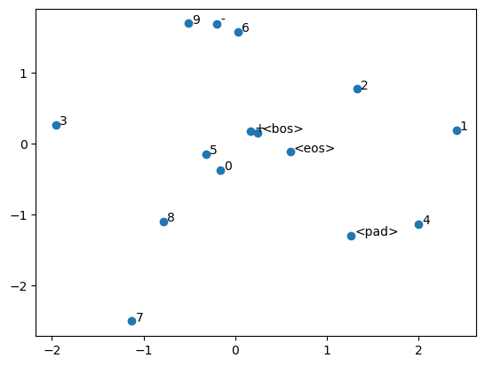

```python
### BEGIN ANSWER
embedding = torch.nn.Embedding(len(vocab), 2)
### END ANSWER

# embed all tokens of our vocabulary
x = torch.arange(len(vocab))
emb = embedding(x).detach().cpu().numpy()

plt.scatter(emb[:, 0], emb[:, 1]);
for i, token in enumerate(vocab.tokens):
    plt.annotate(token, (emb[i,0]+0.04, emb[i,1]))
```

As always, we need to balance the complexity of our networks: a larger embedding will increase the number of parameters in our model, but increase the risk of overfitting.

**6.2 j Add comment(j) Would this 2-dimensional embedding space be large enough for our problem? (1 point)**

Answer:

Probably not in practice, especially because the embedding dimensionality is also used as the size of vectors in each intermediate layer of the transformer model.

But you can immagine encoding the tokens '0'..'9' in a line, and '+' and '-' as +1 and -1 in an orthogonal direction. Perhaps that is enough to do addition.

*Grading:*

- 1 point for a good argument.

Instead of using an embedding, we could also use a simple one-hot encoding to map the words in the vocabulary to feature vectors. However, practical applications of natural language processing never do this. Why not?

**6.2 k Add comment(k) Explain the practical advantage of embeddings over one-hot encoding. (1 point)**

Answer:

When using one-hot encoding the size of the output depends on the size of the vocabulary. To go to a fixed size you could use a linear layer after that, but this is computationally wasteful, because you are multiplying vectors that are mostly 0.

*Score: Either an answer about wasteful computation or about varying ouput size is worth 1 point.*

## 6.3 `torch.nn.Transformer` (8 points)

[figure not shown]

We now have all required inputs for our transformer.

Consult the documentation for the [`torch.nn.Transformer`](https://pytorch.org/docs/stable/generated/torch.nn.Transformer.html) class of PyTorch. This class implements a full Transformer as described in ["Attention Is All You Need"](https://arxiv.org/pdf/1706.03762.pdf), the paper that introduced this architecture.

The `Transformer` class implements the main part of the of the Transformer architecture, shown highlighted in the image on the left (see also Fig. 1 in "Attention Is All You Need").

For a given input sequence, it applies one or more encoder layers, followed by one or more decoder layers, to compute an output sequence that we can then process further.

Because the `Transformer` class takes care of most of the complicated parts of the model, we can concentrate providing the inputs and outputs: the grayed-out areas in the image.

Check out the parameters for the `Transformer` class and the inputs and outputs of its `forward` function.

**6.3 a Add comment(a) Which parameter of the `Transformer` class should we base on our embedding? (1 point)**

Answer: The first argument, `d_model` — the number of expected features in the encoder/decoder inputs

*Grading:*

- 1 point for the correct answer.

**6.3 b Add comment(b) Given fixed input and output dimensions, which parameters of the `Transformer` can we use to change the complexity of our network? (1 point)**

Answer:

`num_encoder_layers`, `num_decoder_layers`, and `dim_feedforward`. The first two control the depth of the network, the controls the complexity of the MLP layer.

Arguably `dropout` controls the complexity as well by doing regularization.

The dimensionality of the key, query, and value in `torch.MultiHeadAttention` is `d_model//nhead`, so the number of parameters stays the same if you change `nhead`. If you increase the number of heads, each head gets smaller vectors, so the overall complexity stays about the same.

*Grading*

- 1 point only if the `num_*_layers` and `dim_feedforward` are mentioned.
- Mentioning `dropout` is ok, mentioning other parameters is incorrect (0 points).

**6.3 c Add comment(c) When using the `Transformer` class, where should we use the masks that we defined earlier? (1 point)**

Answer:

In the call to `forward` or `__call__` (that is, when applying the transformer): `tgt_mask`, `src_key_padding_mask`, and `tgt_key_padding_mask`.

*Grading:*

- 1 point for the correct answer.

### Building a network

**6.3 d Add comment(d) Complete the code for the TransformerNetwork. (5 points)**

Construct a network with the following architecture (see the image in the previous section for an overview):

1. An embedding layer that embeds the input tokens into a space of size `dim_hidden`.
2. A dropout layer (not shown in the image).
3. A [Transformer](https://pytorch.org/docs/stable/generated/torch.nn.Transformer.html) with the specified parameters (`dim_hidden`, `num_heads`, `num_layers`, `dim_feedforward`, and `dropout`).  
   Note: you will need to pass `batch_first=True`, to indicate that the first dimension runs over the batch and not over the sequence.
4. A final linear prediction layer that takes the output of the transformer to `dim_vocab` possible classes.

Don't worry about positional encoding for now, we will add that later.

The `forward` function should generate the appropriate masks and combine the layers defined in `__init__` to compute the output.

*Grading:*

- Max. 2 points for the `__init__` function. -1 point per mistake.
- Max. 2 points for the `forward` function. -1 point per mistake.
- 1 point for the positional encoding.

```python
class TransformerNetwork(torch.nn.Module):
    def __init__(self,
                 dim_vocab=len(vocab), padding_token=vocab['<pad>'],
                 num_layers=2, num_heads=4, dim_hidden=64, dim_feedforward=64,
                 dropout=0.01, positional_encoding=False):
        super().__init__()
        self.padding_token = padding_token
        ### BEGIN ANSWER
        self.embedding    = torch.nn.Embedding(dim_vocab, dim_hidden)
        self.dropout      = torch.nn.Dropout(dropout)
        self.transformer  = torch.nn.Transformer(dim_hidden, num_heads, num_layers,
                                                 num_layers, dim_feedforward,
                                                 dropout=dropout, batch_first=True)
        self.predict      = torch.nn.Linear(dim_hidden, dim_vocab)
        if positional_encoding:
            self.pos_encoding = PositionalEncoding(dim_hidden)
        else:
            self.pos_encoding = torch.nn.Identity()
        ### END ANSWER

    def forward(self, src, tgt):
        ### BEGIN ANSWER
        src_padding_mask = generate_padding_mask(src, self.padding_token)
        tgt_padding_mask = generate_padding_mask(tgt, self.padding_token)
        tgt_mask = generate_square_subsequent_mask(tgt.shape[1], tgt.device)
        src_emb = self.dropout(self.pos_encoding(self.embedding(src)))
        tgt_emb = self.dropout(self.pos_encoding(self.embedding(tgt)))
        out = self.transformer(src_emb, tgt_emb,
                               tgt_mask=tgt_mask,
                               src_key_padding_mask=src_padding_mask,
                               memory_key_padding_mask=src_padding_mask,
                               tgt_key_padding_mask=tgt_padding_mask,
                              )
        return self.predict(out)
        ### END ANSWER
```

**(e) Try the transformer with an example batch.**

```python
net = TransformerNetwork(dim_feedforward=72)
x, y = next(iter(train_loader))
y_prev = shift_targets(y)

print('x.shape', x.shape)
print('y.shape', y.shape)
print('y_prev.shape', y_prev.shape)

y_pred = net(x, y_prev)
print('y_pred.shape', y_pred.shape)

# check the shape against what we expected
np.testing.assert_equal(list(y_pred.shape), [y.shape[0], y.shape[1], len(vocab)])
```

```
x.shape torch.Size([125, 9])
y.shape torch.Size([125, 6])
y_prev.shape torch.Size([125, 6])
y_pred.shape torch.Size([125, 6, 15])
```

We can convert these predictions to tokens (but they're obviously random):

```python
print(decode_tokens(torch.argmax(y_pred, dim=2))[:5])
```

```
[['0' '2' '2' '0' '3' '3']
 ['0' '6' '6' '3' '4' '6']
 ['0' '6' '3' '2' '<pad>' '1']
 ['3' '6' '<bos>' '3' '<bos>' '1']
 ['0' '<bos>' '<bos>' '<pad>' '<bos>' '<bos>']]
```

```python
# Check that the transformer is defined correctly
assert isinstance(net.embedding, torch.nn.Embedding)
assert isinstance(net.dropout, torch.nn.Dropout)
assert isinstance(net.transformer, torch.nn.Transformer)
assert isinstance(net.predict, torch.nn.Linear)
# Check parameters of transformer
assert net.transformer.d_model == 64
assert net.transformer.nhead == 4
assert net.transformer.batch_first == True
assert net.transformer.encoder.num_layers == 2
assert net.transformer.decoder.num_layers == 2
assert net.transformer.encoder.layers[0].linear1.out_features == 72
assert net.dropout.p == 0.01
assert net.transformer.encoder.layers[0].dropout.p == 0.01
# Check that the forward function behaves correctly
net.train(False)
assert torch.all(torch.isclose( \
            net(x, y_prev), \
            net(torch.cat((x,torch.tensor(vocab['<pad>']).expand(x.shape[0], 5)), axis=1), y_prev), atol=1e-5)), \
       "Adding padding to x should not affect the output of the network. Check src_key_padding_mask and memory_key_padding_mask. The former controls self attention to padding tokens in the encoder, the latter controls cross attention from decoder to encoder."
assert torch.all(torch.isclose( \
            net(x, y_prev), \
            net(x, torch.cat((y_prev,torch.tensor(vocab['<pad>']).expand(y.shape[0], 5)), axis=1))[:,:-5], atol=1e-5)), \
       "Adding padding to y should not affect the output of the network. Check tgt_key_padding_mask."
assert torch.all(torch.isclose( \
            net(x, y_prev)[:,:2], \
            net(x, y_prev[:,:2]), atol=1e-5)), \
       "The presence of later tokens in y should not affect the output for earlier tokens. Check tgt_mask."
assert torch.all(torch.isclose( \
            net(x, y_prev), \
            net(torch.flip(x, [1]), y_prev), atol=1e-5)), \
       "Order of x should not matter for a transformer network. Check src_mask."
assert not torch.all(torch.isclose( \
            net(x, torch.flip(y_prev, [1])), \
            torch.flip(net(x, y_prev), [1]), atol=1e-5)), \
       "Order of y should matter for a transformer network. Check tgt_mask."
```

## 6.4 Training (10 points)

### Training loop

We will base the training code on last week's code. A complication in computing the loss and accuracy are the padding tokens. So, before we work on the training loop itself, we need to update the `accuracy` function so it ingores these `<pad>` tokens. Let's do this in a generic way

**6.4 a Add comment(a) Copy the `accuracy` function from last week, and add a parameter `ignore_index`. The tokens with `true_y == ignore_index` should be ignored. (1 point)**

Hint: you can select elements from a tensor with `some_tensor[include]` where `include` is a tensor of booleans.

*Grading:*

- 1 point for a correct implementation that passes the tests below

```python
def accuracy(pred_y, true_y, ignore_index=None):
### BEGIN ANSWER
    # Computes the mean accuracy.
    # pred_y:       raw network output (before softmax); shape (samples, classes)
    # true_y:       true class labels; shape (samples)
    # ignore_index: (optional) class to ignore
    pred_y = torch.argmax(pred_y, axis=1).to(true_y.dtype)
    correct = (pred_y == true_y).to(torch.float32)
    if ignore_index is not None:
        # Don't look at positions with the ignored token
        correct = correct[true_y != ignore_index]
    return torch.mean(correct)
### END ANSWER
```

```python
# Test the accuracy function.
assert accuracy(torch.tensor([[1,0,0],[0.4,0.5,0.1],[0,1,0],[0.4,0.1,0.5]]), torch.tensor([0,1,2,2]), 1) == 2/3
assert accuracy(torch.tensor([[1,0,0],[0.4,0.5,0.1],[0,1,0],[0.4,0.1,0.5]]), torch.tensor([0,1,2,2]), 2) == 1
assert accuracy(torch.tensor([[1,0,0],[0.4,0.5,0.1],[0,1,0],[0.4,0.1,0.5]]), torch.tensor([0,1,2,2]), 3) == 3/4
assert accuracy(torch.tensor([[1,0,0],[0.4,0.5,0.1],[0,1,0],[0.4,0.1,0.5]]), torch.tensor([2,2,1,2]), 2) == 1
```

**6.4 b Add comment(b) Write a training loop for the transformer model. (4 points)**

See last week's assignment for inspiration. The code is mostly the same with the following changes:

- The cross-entropy loss function and accuracy should ignore all `<pad>` tokens. (Use `ignore_index`, see the [documentation of CrossEntropyLoss](https://pytorch.org/docs/stable/generated/torch.nn.CrossEntropyLoss.html).)
- The network expects `y_prev` as an extra input.
- The output of the network contains a batch of N samples, with maximum length L, and gives logits over C classes, so it has size (N,L,C). But `CrossEntropyLoss` and `accuracy` expect a tensor of size (N,C,L). You can use [torch.Tensor.transpose](https://pytorch.org/docs/stable/generated/torch.transpose.html) to change the output to the right shape.

*Grading:*

- 1 point for a working training loop.
- 1 point for correct use of `ignore_index` in loss and accuracy.
- 1 point for building `y_pred` and passing it to `net`.
- 1 point for correct use of `y_hat.transpose(1,2)`.
- Note: your train function might differ in terms of ploting and printing metrics.

```python
### BEGIN ANSWER
class Plotter:
    """For plotting data in animation."""
    # Based on d2l.Animator
    def __init__(self, xlabel=None, ylabel=None, legend=None, xlim=None,
                 ylim=None, xscale='linear', yscale='linear',
                 fmts=('-', 'm--', 'g-.', 'r:'), nrows=1, ncols=1,
                 figsize=(3.5, 2.5)):
        # Incrementally plot multiple lines
        if legend is None:
            legend = []
        self.fig, self.axes = plt.subplots(nrows, ncols, figsize=figsize)
        if nrows * ncols == 1:
            self.axes = [self.axes,]
        # Use a function to capture arguments
        def config_axes():
            axis = self.axes[0]
            axis.set_xlabel(xlabel), axis.set_ylabel(ylabel)
            axis.set_xscale(xscale), axis.set_yscale(yscale)
            axis.set_xlim(xlim),     axis.set_ylim(ylim)
            if legend:
                axis.legend(legend)
            axis.grid()
        self.config_axes = config_axes
        self.X, self.Y, self.fmts = None, None, fmts

    def add(self, x, y):
        # Add multiple data points into the figure
        if not hasattr(y, "__len__"):
            y = [y]
        n = len(y)
        if not hasattr(x, "__len__"):
            x = [x] * n
        if not self.X:
            self.X = [[] for _ in range(n)]
        if not self.Y:
            self.Y = [[] for _ in range(n)]
        for i, (a, b) in enumerate(zip(x, y)):
            if a is not None and b is not None:
                self.X[i].append(a)
                self.Y[i].append(b)
        self.axes[0].cla()
        for x, y, fmt in zip(self.X, self.Y, self.fmts):
            self.axes[0].plot(x, y, fmt)
        self.config_axes()
        display.display(self.fig)
        display.clear_output(wait=True)
### END ANSWER
```

```python
### BEGIN ANSWER
class Metrics:
    """Accumulate mean values of one or more metrics."""
    def __init__(self, n):
        self.count = 0
        self.sum = (0,) * n
    def add(self, count, *values):
        self.count += count
        self.sum = tuple(s + count * v for s,v in zip(self.sum,values))
    def mean(self):
        return tuple(s / self.count for s in self.sum)

def evaluate(net, test_loader, loss_function, device=device):
    """
    Evaluate a model on the given dataset.
    Return loss, accuracy
    """
    with torch.no_grad():
        net.eval()
        metrics = Metrics(2)
        for x, y in test_loader:
            x = x.to(device)
            y = y.to(device)
            # predict next token based on previous tokens
            y_prev = shift_targets(y)
            pred_y = net(x, y_prev)
            # Note: network has classes as last dim, CrossEntropyLoss expects classes as dim=1
            pred_y = pred_y.transpose(1,2)
            loss = loss_function(pred_y, y)
            acc = accuracy(pred_y, y)
            metrics.add(len(y), loss.item(), acc)
        return metrics.mean()
### END ANSWER
```

```python
def train(net, data_loaders, num_epochs=100, lr=0.001, optimizer=torch.optim.Adam, device=device):
    """
    Train a network on the given data set.
    After every epoch compute validation loss and accuracy.
    """
    ### BEGIN ANSWER
    net.to(device)
    train_loader = data_loaders['train']
    num_batches = len(train_loader)
    optimizer = optimizer(net.parameters(), lr=lr)
    padding_token = vocab['<pad>']
    bos_token = vocab['<bos>']
    loss_function = torch.nn.CrossEntropyLoss(ignore_index=padding_token)

    plotter = Plotter(xlabel='epoch', xlim=[1, num_epochs],
                      legend=['train loss', 'train acc', 'val loss', 'val acc'])
    start_time = time.time()
    for epoch in range(num_epochs):
        # Sum of training loss, sum of training accuracy, no. of examples
        net.train()
        metrics = Metrics(2)
        for i, (x, y) in enumerate(train_loader):
            optimizer.zero_grad()
            x = x.to(device)
            y = y.to(device)
            # predict next token based on true previous token
            y_prev = shift_targets(y, bos_token)
            pred_y = net(x, y_prev)
            # Note: network has classes as last dim, CrossEntropyLoss expects classes as dim=1
            pred_y = pred_y.transpose(1,2)
            # optimizer step
            loss = loss_function(pred_y, y)
            loss.backward()
            optimizer.step()
            with torch.no_grad():
                acc = accuracy(pred_y, y, ignore_index=padding_token)
                metrics.add(len(y), loss.item(), acc)

        # Update plotter
        train_loss, train_acc = metrics.mean()
        val_loss, val_acc = evaluate(net, data_loaders['val'], loss_function=loss_function, device=device)
        plotter.add(epoch + 1, (train_loss, train_acc, val_loss, val_acc))

    train_loss, train_acc = metrics.mean()
    train_time = time.time() - start_time
    print(f'train loss {train_loss:.3f}, train acc {train_acc:.3f}, '
          f'val loss {val_loss:.3f}, val acc {val_acc:.3f}')
    print(f'{metrics.count * num_epochs / train_time:.1f} examples/sec '
          f'on {str(device)}')
    ### END ANSWER
```

### Experiment

**(c) Train a transformer network. Use 100 epochs with a learning rate of 0.001 (no points)**

```
train loss 1.122, train acc 0.604, val loss 1.798, val acc 0.352
2471.2 examples/sec on cpu
```

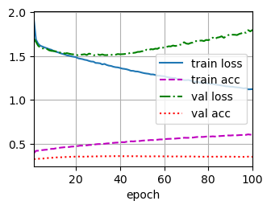

```python
### BEGIN ANSWER
net = TransformerNetwork().to(device)
train(net, data_loaders)
### END ANSWER
```

**6.4 d Add comment(d) Briefly discuss the results. Has the training converged? Is this a good calculator? (1 point)**

Answer:

Training has not converged, but the network is overfitting. The validation accuract is low, so this is not a good model to use as a calculator.

*Grading:*

- 0.5 point for the correct answer about convergence
- +0.5 point for explaning why it is not a good calculator.
- Just saying "it is not a good calculator" without mentining validation loss or overfitting: no points for the second part (so max 0.5 points for the question)

**6.4 e Add comment(e) Run the trained network with input `"123+123"` and `"321+321"`. (1 point)**

*Grading:*

- The output should be similar to the answer model, and not match the target output at all.

```python
def predict(net, q, a):
    # Run net to predict the output given the input `q` and y_prev based on `a`.
    # Return predicted y
    with torch.no_grad():
        ### BEGIN ANSWER
        x = torch.tensor(tokenize_and_encode(q), device=device)[None, :]
        y = torch.tensor(tokenize_and_encode(a), device=device)[None, :]
        y_prev = shift_targets(y)
        return net(x, y_prev)[0]
        ### END ANSWER

for src, tgt in [('123+123', '246'), ('321+321', '642')]:
    print(f'For {src}={tgt}')
    y_pred = predict(net, src, tgt)
    print('  y_pred[0]', y_pred[0])
    print('  encoded', torch.argmax(y_pred, dim=-1))
    print('  tokens', decode_tokens(torch.argmax(y_pred, dim=-1)))
    print()
```

```
For 123+123=246
  y_pred[0] tensor([-10.1190,   0.6350,  -2.3705,   0.3468,   2.5027,   3.4300,   2.2683,
          0.8870,   2.1399,   0.7360,   0.8620,  -0.7181,  -8.6308,  -6.7574,
         -9.8209])
  encoded tensor([ 5,  6,  5, 13])
  tokens ['3' '4' '3' '<eos>']

For 321+321=642
  y_pred[0] tensor([-10.1190,   0.6350,  -2.3705,   0.3468,   2.5027,   3.4300,   2.2683,
          0.8870,   2.1399,   0.7360,   0.8620,  -0.7181,  -8.6308,  -6.7574,
         -9.8209])
  encoded tensor([ 5,  5,  5, 13])
  tokens ['3' '3' '3' '<eos>']
```

**6.4 f Add comment(f) Compare the predictions for the first element of y with the two different inputs. Can you explain what happens? (1 point)**

Answer:

The predictions for the first element of `y` are identical. When not using positional encoding, all tokens are treated equally, so the encoder's output is effectively the same for the two questions (only in a different order). The first outputs for the decoder will therefore also be the same. Later outputs can differ, because `y_prev` will be different.

*Grading:*

- 1 point for correct answer and explanation.
- The answer must include something about tokens in all positions being equivalent without positional encoding.

**6.4 g Add comment(g) Does the validation accuracy estimate how often the model is able to answers formulas correctly? Explain your answer. (1 point)**

Answer:

The validation accuracy is measured per token. An error rate of 20% per token would still result in around a 50% error rate for the whole answer. It would be better to measure the accuracy for the entire token sequence. Still, a very high accuracy does put a lower bound on the whole answer accuracy.

*Grading:*

- 1 point for a correct answer and explanation.

**6.4 h Add comment(h) If the forward function takes the shifted output `y_prev` as input, how can we use it if we don't know the output yet? (1 point)**

Answer:

The prediction must be done one token at a time. The predicted token becomes the input `y_prev` for predicting the next token.

*Grading:*

- 1 point for a correct answer.

## 6.5 Positional encoding (5 points)

We did not yet include positional encoding in the network. PyTorch does not include such an encoder. So, here we define such a module ourselves:

```python
class PositionalEncoding(nn.Module):
    """Positional encoding."""
    def __init__(self, num_hiddens, max_len=100):
        super().__init__()
        # Create a long enough matrix of position encodings P
        positions = torch.arange(max_len, dtype=torch.float32)
        freqs = torch.pow(max_len, (1 + 2 * torch.arange(num_hiddens / 2)) / num_hiddens)
        X = positions[:,None] / freqs[None,:]
        self.P = torch.zeros((max_len, num_hiddens))
        self.P[:, 0::2] = torch.sin(X)
        self.P[:, 1::2] = torch.cos(X)

    def forward(self, X):
        return X + self.P[None, :X.shape[1], :].to(X.device)
```

**(a) Add positional encoding to the TransformerModel. (point given in earlier question)**

```python
# TODO: Modify the code in 6.3d.
```

**6.5 b Add comment(b) Construct and train a network with positional encoding (1 point)**

*Grading:*

- 1 point for correct code.

```
train loss 0.065, train acc 0.979, val loss 0.041, val acc 0.767
2493.8 examples/sec on cpu
```

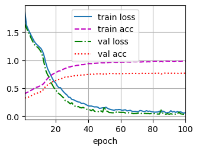

```python
### BEGIN ANSWER
net_pos = TransformerNetwork(positional_encoding=True).to(device)
train(net_pos, data_loaders)
### END ANSWER
```

**6.5 c Add comment(c) How does the performance of a model with positional encoding compare to a model without? (1 point)**

Answer:

The performance is much better with positional encoding. As expected, some form of positional encoding is needed for this task.

*Grading:*

- 1 point for the correct observation.

**(d) Run the trained network with input `"123+123"` and `"321+321"`. (no points)**

```python
### BEGIN ANSWER
for src, tgt in [('123+123', '246'), ('321+321', '642')]:
    print(f'{src}={tgt}')
    y_pred = predict(net_pos, src, tgt)
    print('  y_pred[0]', y_pred[0])
    print('  encoded', torch.argmax(y_pred, dim=-1))
    print('  tokens', decode_tokens(torch.argmax(y_pred, dim=-1)))
    print()
### END ANSWER
```

```
123+123=246
  y_pred[0] tensor([ -2.2373,  -4.8701,  -6.6299,  12.0426,  18.6714,  11.6218,  -2.5436,
        -16.7457, -12.8434,  -2.3928,  -0.7214,  -5.0969,  -2.1290,  -0.5183,
         -0.8202])
  encoded tensor([ 4,  6,  8, 13])
  tokens ['2' '4' '6' '<eos>']

321+321=642
  y_pred[0] tensor([ -3.6056,  -2.7674, -10.1232,  -4.6420,  -9.9681,  -7.3780,  -0.0530,
         13.2408,  21.1353,   8.2820,  -3.8767,  -6.8705,  -2.9300,   2.1938,
         -2.4586])
  encoded tensor([ 8,  6,  4, 13])
  tokens ['6' '4' '2' '<eos>']
```

**6.5 e Add comment(e) Compare the predictions for the first element of y with what you found earlier. Can you explain what happens? (1 point)**

Answer:

The first elements of `y` are not the same for the two questions. Earlier, without positional encoding, they were the same. The positional encoding allows the order of the token sequence to matter.

*Grading:*

- 1 point for a correct observation.
- The answer should compare to 5.4e.

**6.5 f Add comment(f) Explain in your own words why positional encoding is used in transformer networks. (1 point)**

Answer:

Positional encoding is used to encode the relative position of elements in the input sequence. Because the transformer treats a sequence as a bag of tokens, there is no way to extract the other of the tokens. The positional encoding adds this information to the representation.

*Grading:*

- 1 point for a correct argument.

**6.5 g Add comment(g) Look at the learning curve. Can you suggest a way to improve the model? (1 point)**

Answer:

Training has mostly converged, but not fully. Training for longer might help.

There is little overfitting, and the training accuracy is also not perfect. So, a more complex network could better fit the data.

*Grading:*

- 1 point for at least one of these suggestions.

**(h) Optional: if time permits, try to train an even better model**

Answer:

This is an open question. Some improvements that can work are:

- Repalce ReLU activations with GeLU.
- Increase the number of layers in the transformer network.

## 6.6 Predicting for new samples (5 points)

Predicting an output given a new sample requires an appropriate search algorithm (see [d2l chapter 10.8](https://d2l.ai/chapter_recurrent-modern/beam-search.html)). Here, we will implement the simplest form: a greedy search algorithm that selects the token with the highest probability at each time step.

**6.6 a Add comment(a) Describe this search strategy in pseudo-code. (1 point)**

Answer:

- Let `y = []`
- Repeatedly:
  - Make a prediction with the transformer (as in `predict`)
  - Add the most likely token to `y`
  - Stop if an `'<eos>'` token is predicted or if a maximum length is reached

Note: it would be more efficient to only update the parts of the transformer that have changed, which is the decoder for the new token.

*Grading:*

- 1 point for a reasonable algorithm.

**6.6 b Add comment(b) Implement a greedy search function to predict a sequence using `net_pos`. (2 points)**

*Grading:*

- 1 point for doing predictions in a loop.
- 1 point for picking the most likely token with `torch.argmax`. Be careful about which dimension the maximum is taken over, it should be the last, so dim=2 or dim=-1.
- Stopping on `'<eos>'` is not required.
- Note: this implementation only tracks `y_prev` instead of `y`. Doing either is ok.
- Note: in a greedy algorithm you could also re-pick all tokens in every iteration. That would look like `y = torch.argmax(y_pred, dim=-1)`.

```python
def predict_greedy(net, src, length):
    # predict an output sequence of the given (maximum) length given input string src
    with torch.no_grad():
        ### BEGIN ANSWER
        x = torch.tensor(tokenize_and_encode(src), device=device)[None, :]
        # initial input
        bos = torch.tensor(vocab['<bos>'], device=device).expand(x.shape[0], 1)
        y_prev = bos
        for t in range(length):
            # predict the next token
            y_pred = net(x, y_prev)
            # greedily take the token with the highest value and
            # append it to the input for the next step
            y_prev = torch.cat((y_prev, torch.argmax(y_pred, dim=-1)[:, -1:]), dim=1)
            # stop at '<eos>'
            if y_prev[0,-1] == vocab['<eos>']:
                break
        # return the final sequence of predicted tokens
        return y_prev[0,1:]
        ### END ANSWER

predicted_sequence = predict_greedy(net_pos, '123+123', 6)
print(decode_tokens(predicted_sequence))
```

```
['2' '4' '6' '<eos>']
```

**6.6 c Add comment(c) Does this search strategy give a high-quality prediction? Why, or why not? (1 point)**

Answer:

Yes, it produces good predictions, because the network preforms very well on a token level.

*Grading:*

- 1 point for a correct answer.
- If your network performs differently the answer here should reflect that.

**6.6 d Add comment(d) What alternative search strategy could we use to improve the predictions? Why would this help? (1 point)**

Answer:

An alternative is beam search. This could lead to better predictions in terms of overall likelihood. For example, when computing `25+25` it might be easier to see that the output should start with `5`, because otherwise the next token would have to be 10, which is impossible.

But the differences between greedy search and beam search will likely be very small.

*Grading:*

- 1 point for noting that beam search might help a tiny bit.

## 6.7 Discussion (4 points)

Last week, we looked at recurrent neural networks such as the LSTM. Both recurrent neural networks and transformers work with sequences, but in recent years the transformer has become more popular than the recurrent models.

**6.7 a Add comment(a) An advantage of transformers over recurrent neural is that they can be faster to train. Why is that? (1 point)**

Answer:

Transformers can train in parallel for all tokens, whereas RNNs are inherently sequential.

*Grading:*

- 1 point for a correct answer about parallel training.

**6.7 b Add comment(b) Does this advantage also hold when predicting outputs for new sequences? Why, or why not? (1 point)**

Answer:

No, predicting tokens is still sequential, because the previous predicted token is given as an input to the decoder in the form of `y_prev`.

Aside: it is possible to construct transformer-like networks that do not have this input, but that tends to not work as well in practice.

*Grading:*

- 1 point for a correct answer.

**6.7 c Add comment(c) Why is positional encoding often used in transformers, but not in convolutional or recurrent neural networks? (1 point)**

Answer:

RNNs do not need positional encoding, because the position of the tokens can be inferred from the order in which they are given to the network. In a CNN usually the input is assumed to be translation invariant or equivariant, and the network is designed to have this invariance. Adding positional encoding would only defeat that.

*Grading:*

- 1 point for a correct answer about RNNs and/or about CNNs. Note that these are two different arguments.

The structure of a recurrent neural network makes it very suitable for online predictions, such as real-time translation, because it only depends on prior inputs. You can design an architecture where the RNN produces an output token for every input token given to it, and it can produce that output without having to wait for the rest of the input.

Note: 'online' means producing outputs continuously as new input comes in, as opposed to collecting a full dataset and analyzing it afterwards, it has nothing to do with the internet.

**6.7 d Add comment(d) How would a transformer work in an online application? Do you need to change the architecture? (1 point)**

Answer:

You would add more inputs over time. You could use masked self attention also for the encoder, so that new input tokens can only attend to earlier tokens. Then new inputs can be added without having to recompute everything.

A potential issue is the $O(n^2)$ complexity of self attention blocks. RNNs do not have this issue and they can operate with a fixed memory size and computation budget.

*Grading:*

- 1 point for suggesting masked self attention.

## The end

Well done! Please double check the instructions at the top before you submit your results.

*This assignment has 47 points.* Version 735280c / 2024-10-15

## Score form

Something didn't work. Save the following list of scores in a text file and upload to Brightspace:

Download the scores as a text file